# Bear River

Sadie Gill, Mark Tompkins, Erin Cain

June 18, 2019

## Future Data Improvements

None Planned

## Instream Spawning and Rearing Habitat

**Data Source:** [Holton 1985](https://s3-us-west-2.amazonaws.com/cvpiahabitat-r-package/cvpia-sit-model-inputs/Holton1985_BearRiverIFIM.PDF) (pg 21-22)

Instream spawning and rearing habitat for Fall Run Chinook Salmon in the Bear River is based on data from an instream flow study led by Booker Holton (Holton Associates) in partnership with the California Department of Fish and Game. Holton used the Instream Flow Incremental Methodology (IFIM) and collected data from two representative stations below the diversion dam on Bear River. The WUA graphs for Chinook Salmon spawning and juvenile rearing are provided on pages 21 and 22. The instream spawning and rearing habitat data was provided to us by Mark Gard from the U.S. Fish and Wildlife Service in a spreadsheet (see ‘~/cvpiaHabitat/data-raw/mark_gard_data/IFIMWUA.xlsx’). Mark Gard instructed us to use A1:D5 of the ‘BearR’ tab within his ‘IFIMWUA.xlsx’.

### Combine Spawning and Rearing Data

The instream spawning and juvrnile rearing habitat data described above for Fall Run Chinook Salmon (FR) is combined for use in the DSM in the following format. Units are in square feet per 1000 feet.

| flow_cfs | FR_spawn_wua | FR_juv_wua | watershed |
| --- | --- | --- | --- |
| 30 | 2000 | 30 | Bear River |
| 70 | 6500 | 70 | Bear River |
| 140 | 15000 | 150 | Bear River |
| 180 | 21000 | 170 | Bear River |

### Spawning WUA

The instream spawning habitat weighted usable areas for Fall Run Chinook Salmon in the Bear River.

#### Spawning WUA Plot

The following plot shows the weighted usable spawning area in square feet per thousand feet of river for Fall Run Chinook Salmon. These area per length rates are multiplied by the total spawning reach length mapped by the SIT.

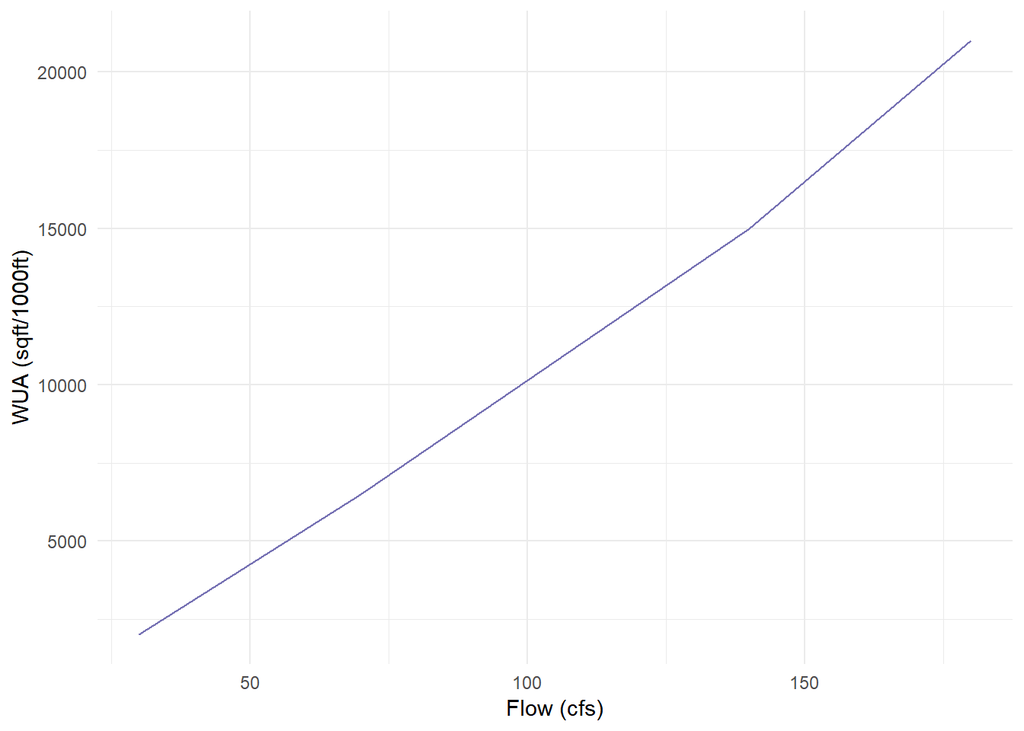

### Rearing WUA

The juvenile instream rearing habitat weighted usable areas for Fall Run Chinook Salmon in the Bear River.

#### Rearing WUA Plot

The following plot shows the weighted usable rearing area in square feet per thousand feet of river for Fall Run Chinook Salmon juvenile. These rates are multiplied by the total rearing reach length mapped by the SIT.

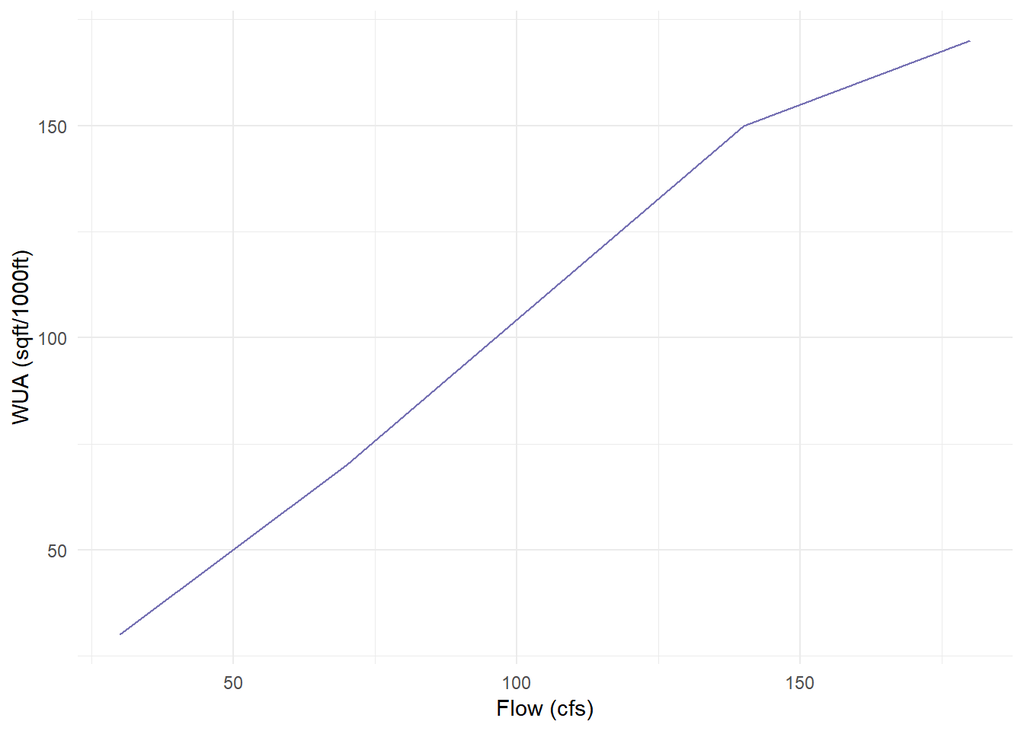